# Analyzing Popularity

### Marc Anthony B Reyes

Growth Data Analyst Applicant | hello@marcreyes.ph | (+63)9129152323

- Part 1: Identifying Popular Artist and Music Using the Taste Profile
- Part 2: Identifying Popular Music with Billboard Hot 100 Data
- Part 3: Trend of Genre Throughout the Years

## Part 1: Identifying Popular Artist and Music Using the Taste Profile

On this part, we will be identifying popular artist and music using the taste profile triplets data. The triplets data file contains the `user_id`, `song_id`, and `listen_count` and we'll be analyzing popularity based on distribution of these variables.

```python
# Library imports
import numpy as np
import time
from sklearn.externals import joblib
from lib import Recommenders, Evaluation
from bs4 import BeautifulSoup
from datetime import date, datetime, timedelta
from dateutil import parser
from matplotlib import rcParams
import copy
import matplotlib.pyplot as plt
import numpy as np
import pandas as pd
import pickle
import re
import requests
import string
import warnings

plt.style.use('fivethirtyeight')
rcParams['font.size'] = 15
```

```python
# Read the taste profile triplets data and store into a dataframe
song_df_1 = pd.read_csv('data/taste_profile_abstract.csv',header=None)
song_df_1.columns = ['user_id', 'song_id', 'listen_count']

# Read the song data and store into a dataframe
song_df_2 =  pd.read_csv('data/song_data_with_genre_and_country.csv', index_col=0)

# Merge the two dataframes with song_id as the key with left join
song_df = pd.merge(song_df_1, song_df_2.drop_duplicates(['song_id']), on="song_id", how="left")
```

```python
# Show first five (5) rows in the dataframe
song_df.head()
```

|  | user_id | song_id | listen_count | audio_md5 | danceability | duration | end_of_fade_in | energy | bars_confidence | bars_start | ... | similar_artists | release | release_7digitalid | song_hotttnesss | title | track_7digitalid | artist_mbtags | year | genre_id | country |
| --- | --- | --- | --- | --- | --- | --- | --- | --- | --- | --- | --- | --- | --- | --- | --- | --- | --- | --- | --- | --- | --- |
| 0 | b80344d063b5ccb3212f76538f3d9e43d87dca9e | SOAKIMP12A8C130995 | 1 | NaN | NaN | NaN | NaN | NaN | NaN | NaN | ... | NaN | NaN | NaN | NaN | NaN | NaN | NaN | NaN | NaN | NaN |
| 1 | b80344d063b5ccb3212f76538f3d9e43d87dca9e | SOBBMDR12A8C13253B | 2 | NaN | NaN | NaN | NaN | NaN | NaN | NaN | ... | NaN | NaN | NaN | NaN | NaN | NaN | NaN | NaN | NaN | NaN |
| 2 | b80344d063b5ccb3212f76538f3d9e43d87dca9e | SOBXHDL12A81C204C0 | 1 | 8c3781d6d78aa9a5795211d3f3e481fc | 0.0 | 311.84934 | 0.061 | 0.0 | 0.0 | 0.0 | ... | 0.0 | Graduation | 130573.0 | NaN | Stronger | 1351505.0 | 0.0 | 2007.0 | Rap | NaN |
| 3 | b80344d063b5ccb3212f76538f3d9e43d87dca9e | SOBYHAJ12A6701BF1D | 1 | bcfaf82960d7ff29d1954b1880cc487c | 0.0 | 201.63873 | 0.000 | 0.0 | 0.0 | 0.0 | ... | 0.0 | In Between Dreams | 221729.0 | 0.785447 | Constellations | 2424087.0 | 0.0 | 2005.0 | Pop_Rock | NaN |
| 4 | b80344d063b5ccb3212f76538f3d9e43d87dca9e | SODACBL12A8C13C273 | 1 | a9ce6437c5c3e461fcd5820c7820b51d | 0.0 | 235.28444 | 0.194 | 0.0 | 0.0 | 0.0 | ... | 0.0 | There Is Nothing Left To Lose | 298758.0 | 0.986142 | Learn To Fly | 3360473.0 | 0.0 | 1999.0 | Pop_Rock | NaN |

5 rows × 56 columns

```python
# Create a new column and stores values of the conatenated title
# and artist_name on its rows
song_df['song'] = song_df['title'].map(str) + " - " + song_df['artist_name']
```

### Showing the most popular songs, artists, and countries with most play counts in the dataset

```python
# Create a new dataframe and count numbers of plays of each songs
song_grouped = song_df.groupby(['song']).agg({'listen_count': 'count'}).reset_index()
# Get the sum of all play/listen counts
grouped_sum = song_grouped['listen_count'].sum()
# Get the percentage of the row listen count with respect to the grouped_sum
song_grouped['percentage']  = song_grouped['listen_count'].div(grouped_sum)*100
# Sort the first 100 values in descending order
song_grouped.sort_values(['listen_count', 'song'], ascending = [0,1]).head(100)
```

|  | song | listen_count | percentage |
| --- | --- | --- | --- |
| 3690 | Sehr kosmisch - Harmonia | 8277 | 0.809397 |
| 5197 | You're The One - Dwight Yoakam | 6412 | 0.627021 |
| 3508 | Revelry - Kings Of Leon | 6145 | 0.600912 |
| 3682 | Secrets - OneRepublic | 5841 | 0.571184 |
| 4818 | Use Somebody - Kings Of Leon | 3976 | 0.388808 |
| 720 | Canada - Five Iron Frenzy | 3526 | 0.344803 |
| 745 | Catch You Baby (Steve Pitron & Max Sanna Radio... | 3511 | 0.343336 |
| 4479 | The Scientist - Coldplay | 3372 | 0.329744 |
| 820 | Clocks - Coldplay | 3139 | 0.306959 |
| 151 | Alejandro - Lady GaGa | 3032 | 0.296495 |
| 653 | Bulletproof - La Roux | 3009 | 0.294246 |
| 2196 | Invalid - Tub Ring | 2887 | 0.282316 |
| 920 | Creep (Explicit) - Radiohead | 2839 | 0.277622 |
| 5133 | Yellow - Coldplay | 2829 | 0.276644 |
| 3922 | Somebody To Love - Justin Bieber | 2773 | 0.271168 |
| 2624 | Love Story - Taylor Swift | 2409 | 0.235573 |
| 1782 | Heartbreak Warfare - John Mayer | 2316 | 0.226479 |
| 3280 | Party In The U.S.A. - Miley Cyrus | 2253 | 0.220318 |
| 3089 | Nothin' On You [feat. Bruno Mars] (Album Versi... | 2251 | 0.220122 |
| 894 | Cosmic Love - Florence + The Machine | 2224 | 0.217482 |
| 4813 | Uprising - Muse | 2171 | 0.212299 |
| 22 | 16 Candles - The Crests | 2076 | 0.203009 |
| 4148 | Supermassive Black Hole (Album Version) - Muse | 2071 | 0.202520 |
| 626 | Bring Me To Life - Evanescence | 2070 | 0.202423 |
| 493 | Bitter Sweet Symphony - The Verve | 2029 | 0.198413 |
| 197 | All The Right Moves - OneRepublic | 2028 | 0.198315 |
| 5200 | You've Got The Love - Florence + The Machine | 1988 | 0.194404 |
| 3704 | Seven Nation Army - The White Stripes | 1924 | 0.188145 |
| 1542 | Gears - Future Rock | 1858 | 0.181691 |
| 4634 | Tighten Up - The Black Keys | 1855 | 0.181398 |
| ... | ... | ... | ... |
| 2446 | Le Jardin d'Hiver - Jacky Terrasson | 1219 | 0.119204 |
| 3989 | Speed Of Sound - Coldplay | 1205 | 0.117835 |
| 4407 | The Maestro - Beastie Boys | 1198 | 0.117151 |
| 2788 | Mia - Emmy The Great | 1184 | 0.115782 |
| 2945 | My Name Is - Eminem | 1168 | 0.114217 |
| 2080 | I'm Not Calling You A Liar - Florence + The Ma... | 1135 | 0.110990 |
| 850 | Come As You Are - Nirvana | 1133 | 0.110795 |
| 4995 | Whataya Want From Me - Adam Lambert | 1120 | 0.109523 |
| 2932 | My Immortal (Album Version) - Evanescence | 1079 | 0.105514 |
| 911 | Crawling (Album Version) - Linkin Park | 1072 | 0.104829 |
| 3235 | Oxford Comma (Album) - Vampire Weekend | 1070 | 0.104634 |
| 4229 | Te Amo - Rihanna | 1070 | 0.104634 |
| 2855 | Monster - Lady GaGa | 1059 | 0.103558 |
| 1361 | Far Away (Album Version) - Nickelback | 1043 | 0.101994 |
| 2967 | Nah! - Shania Twain | 1038 | 0.101505 |
| 1931 | Howlin For You - The Black Keys | 1022 | 0.099940 |
| 386 | Bad Company - Five Finger Death Punch | 1010 | 0.098767 |
| 4720 | Transparency - White Denim | 991 | 0.096909 |
| 1713 | Hailie's Song - Eminem | 977 | 0.095540 |
| 1248 | Enter Sandman - Metallica | 975 | 0.095344 |
| 3165 | One - Metallica | 968 | 0.094659 |
| 602 | Breakdown - Jack Johnson | 963 | 0.094171 |
| 1810 | Help I'm Alive - Metric | 952 | 0.093095 |
| 217 | Already Gone - Kelly Clarkson | 932 | 0.091139 |
| 2042 | I Will Follow You into the Dark (Album Version... | 930 | 0.090943 |
| 372 | Back Against The Wall - Cage The Elephant | 923 | 0.090259 |
| 2454 | Learn To Fly - Foo Fighters | 917 | 0.089672 |
| 4641 | Tim McGraw - Taylor Swift | 889 | 0.086934 |
| 1154 | Drive - Incubus | 885 | 0.086543 |
| 5000 | When I Grow Up - The Pussycat Dolls | 884 | 0.086445 |

100 rows × 3 columns

```python
# Create a new dataframe and count numbers of plays of each artist
artist_grouped = song_df.groupby(['artist_name']).agg({'listen_count': 'count'}).reset_index()
# Get the sum of all play/listen counts
artist_grouped_sum = artist_grouped['listen_count'].sum()
# Get the percentage of the row listen count with respect to the grouped_sum
artist_grouped['percentage']  = artist_grouped['listen_count'].div(artist_grouped_sum)*100
# Sort the first 100 values in descending order
artist_grouped.sort_values(['listen_count', 'artist_name'], ascending = [0,1]).head(100)
```

|  | artist_name | listen_count | percentage |
| --- | --- | --- | --- |
| 301 | Coldplay | 18447 | 1.803908 |
| 1312 | The Black Keys | 16618 | 1.625053 |
| 731 | Kings Of Leon | 15061 | 1.472796 |
| 623 | Jack Johnson | 15008 | 1.467613 |
| 931 | Muse | 12670 | 1.238983 |
| 979 | OneRepublic | 10820 | 1.058074 |
| 659 | John Mayer | 10493 | 1.026097 |
| 887 | Metallica | 10219 | 0.999303 |
| 513 | Florence + The Machine | 9749 | 0.953342 |
| 1287 | Taylor Swift | 9521 | 0.931046 |
| 1077 | Radiohead | 9343 | 0.913640 |
| 451 | Eminem | 9293 | 0.908750 |
| 1483 | Vampire Weekend | 8448 | 0.826119 |
| 580 | Harmonia | 8277 | 0.809397 |
| 759 | Lady GaGa | 7277 | 0.711608 |
| 785 | Linkin Park | 7071 | 0.691464 |
| 1373 | The New Pornographers | 6899 | 0.674644 |
| 751 | LCD Soundsystem | 6787 | 0.663692 |
| 1301 | The All-American Rejects | 6760 | 0.661052 |
| 1355 | The Killers | 6494 | 0.635040 |
| 418 | Dwight Yoakam | 6412 | 0.627021 |
| 889 | Metric | 5811 | 0.568250 |
| 693 | Justin Bieber | 5328 | 0.521018 |
| 957 | Nickelback | 5306 | 0.518867 |
| 700 | Kanye West | 5247 | 0.513097 |
| 965 | Nirvana | 5244 | 0.512804 |
| 1551 | the bird and the bee | 5229 | 0.511337 |
| 1092 | Red Hot Chili Peppers | 5164 | 0.504981 |
| 692 | Justice | 5022 | 0.491095 |
| 473 | Evanescence | 4944 | 0.483467 |
| ... | ... | ... | ... |
| 1471 | Two Door Cinema Club | 3006 | 0.293953 |
| 75 | Andrew Bird | 2929 | 0.286423 |
| 507 | Fleet Foxes | 2901 | 0.283685 |
| 864 | Massive Attack | 2900 | 0.283587 |
| 1467 | Tub Ring | 2887 | 0.282316 |
| 1218 | Snow Patrol | 2880 | 0.281631 |
| 68 | Amos Lee | 2875 | 0.281143 |
| 600 | Hot Chip | 2875 | 0.281143 |
| 1472 | U2 | 2870 | 0.280654 |
| 466 | Erin McKeown | 2864 | 0.280067 |
| 593 | Hollywood Undead | 2810 | 0.274786 |
| 217 | Bright Eyes | 2734 | 0.267354 |
| 1413 | The Verve | 2679 | 0.261976 |
| 1012 | Passion Pit | 2645 | 0.258651 |
| 135 | Beastie Boys | 2625 | 0.256695 |
| 949 | Neutral Milk Hotel | 2565 | 0.250828 |
| 1382 | The Police | 2558 | 0.250144 |
| 1087 | Ratatat | 2548 | 0.249166 |
| 122 | Band Of Horses | 2521 | 0.246525 |
| 173 | Blink-182 | 2515 | 0.245939 |
| 937 | N.E.R.D. | 2515 | 0.245939 |
| 1406 | The Temper Trap | 2513 | 0.245743 |
| 1307 | The Avett Brothers | 2440 | 0.238604 |
| 609 | Incubus | 2439 | 0.238507 |
| 715 | Kelly Clarkson | 2418 | 0.236453 |
| 1395 | The Shins | 2414 | 0.236062 |
| 51 | Alanis Morissette | 2381 | 0.232835 |
| 1255 | Stone Temple Pilots | 2357 | 0.230488 |
| 1403 | The Strokes | 2318 | 0.226674 |
| 781 | Lily Allen | 2317 | 0.226576 |

100 rows × 3 columns

```python
# Create a new dataframe and count numbers of plays of each country
country_grouped = song_df.groupby(['country']).agg({'listen_count': 'count'}).reset_index()
# Get the sum of all play/listen counts
country_grouped_sum = country_grouped['listen_count'].sum()
# Get the percentage of the row listen count with respect to the grouped_sum
country_grouped['percentage']  = country_grouped['listen_count'].div(country_grouped_sum)*100
# Sort the first 100 values in descending order
country_grouped.sort_values(['listen_count', 'country'], ascending = [0,1]).head(100)
```

|  | country | listen_count | percentage |
| --- | --- | --- | --- |
| 32 | United States | 230505 | 68.005204 |
| 31 | United Kingdom | 43053 | 12.701798 |
| 5 | Canada | 22840 | 6.738417 |
| 10 | France | 5492 | 1.620288 |
| 11 | Germany | 5476 | 1.615568 |
| 13 | Ireland | 4993 | 1.473070 |
| 2 | Barbados | 3689 | 1.088355 |
| 1 | Australia | 2572 | 0.758810 |
| 9 | Finland | 2450 | 0.722816 |
| 20 | Nigeria | 2132 | 0.628998 |
| 26 | Russian Federation | 2078 | 0.613066 |
| 25 | Puerto Rico | 1834 | 0.541080 |
| 28 | Sweden | 1738 | 0.512757 |
| 7 | Colombia | 1345 | 0.396811 |
| 33 | Uruguay | 1166 | 0.344002 |
| 27 | Spain | 1038 | 0.306238 |
| 0 | Argentina | 987 | 0.291192 |
| 21 | Norway | 948 | 0.279686 |
| 29 | Switzerland | 719 | 0.212124 |
| 22 | Peru | 680 | 0.200618 |
| 17 | Mexico | 654 | 0.192948 |
| 14 | Italy | 547 | 0.161380 |
| 23 | Poland | 324 | 0.095589 |
| 6 | Chile | 251 | 0.074052 |
| 19 | New Zealand | 221 | 0.065201 |
| 4 | Brazil | 202 | 0.059595 |
| 3 | Belgium | 145 | 0.042779 |
| 16 | Mali | 118 | 0.034813 |
| 18 | Netherlands | 112 | 0.033043 |
| 15 | Jamaica | 111 | 0.032748 |
| 8 | Egypt | 105 | 0.030978 |
| 30 | Uganda | 101 | 0.029798 |
| 35 | Yemen | 96 | 0.028323 |
| 24 | Portugal | 88 | 0.025962 |
| 34 | Venezuela | 78 | 0.023012 |
| 12 | Greece | 64 | 0.018882 |

```python
# Create a new dataframe and count numbers of plays of each genre
genre_grouped = song_df.groupby(['genre_id']).agg({'listen_count': 'count'}).reset_index()
# Get the sum of all play/listen counts
genre_grouped_sum = genre_grouped['listen_count'].sum()
# Get the percentage of the row listen count with respect to the grouped_sum
genre_grouped['percentage']  = genre_grouped['listen_count'].div(genre_grouped_sum)*100
# Sort the first 100 values in descending order
genre_grouped.sort_values(['listen_count', 'genre_id'], ascending = [0,1])
```

|  | genre_id | listen_count | percentage |
| --- | --- | --- | --- |
| 12 | Pop_Rock | 749148 | 73.258212 |
| 5 | Electronic | 88160 | 8.621052 |
| 13 | Rap | 54697 | 5.348749 |
| 3 | Country | 33046 | 3.231526 |
| 16 | RnB | 32460 | 3.174221 |
| 10 | Latin | 25285 | 2.472587 |
| 6 | Folk | 7230 | 0.707012 |
| 14 | Reggae | 5720 | 0.559351 |
| 15 | Religious | 5697 | 0.557102 |
| 8 | International | 4510 | 0.441027 |
| 9 | Jazz | 4099 | 0.400836 |
| 11 | New Age | 4023 | 0.393404 |
| 2 | Comedy_Spoken | 3542 | 0.346368 |
| 18 | Vocal | 2963 | 0.289748 |
| 0 | Blues | 975 | 0.095344 |
| 4 | Easy_Listening | 548 | 0.053588 |
| 17 | Stage | 276 | 0.026990 |
| 1 | Classical | 139 | 0.013593 |
| 7 | Holiday | 95 | 0.009290 |

### Count number of unique users in the dataset

We will be counting the number of unique users in the dataset. These users have listened at least one of the songs in the song dataset.

```python
# Count the number of unique users in the dataset
len(song_df['user_id'].unique())
```

```
76353
```

## Part 2: Identifying Popular Music with Billboard Hot 100 Data

The original data in A Million Songs dataset came with a song hotness feature. However, around 4500 songs were missing this feature, which is almost half of the subset we were using. Thus, we wanted to find a new way to classify if a song is a hit or not. We decided to use BillBoard Top 100 to determine popularity. If a song has appeared on Top 100 BillBoard at least once, then it will be classified as a hit song.

### Scraping Billboard Hot 100 Data

Scrape Billboard Hot 100 data from Billboard website from 1958 (inception) up to 2012 (latest year in the dataset). We then save the scraped data in a CSV file.

```python
# Function to initiate request on each url and return an lxml file
def get_soup(start_url):
    response = requests.get(start_url)
    page = response.text
    return BeautifulSoup(page, "lxml")
```

```python
# Library imports
from datetime import date, datetime, timedelta

# A function to create list of Billboard Hot 100 urls that catalogue each song going back to 1958
def perdelta(start, end, delta):
    curr = start
    while curr < end:
        yield curr
        curr += delta

# Create an empty list. We will be appending urls here.
urls = []

# Generate chart urls from 9 Aug 1958 to 31 Dec 2012
for suffix in perdelta(date(1958, 8, 9), date(2012, 12, 31), timedelta(days=7)):
    prefix = 'http://www.billboard.com/charts/hot-100/'
    link = prefix + str(suffix)
    urls.append(link)
```

```python
# Show the first three (3) chart urls
urls[:3]
```

[output not shown]

```python
# Function to scrape artists from the soup data
def get_artist(soup):
    artist = soup.find_all(class_="chart-row__artist")
    artists = []
    for item in artist:
        item = item.text.strip()
        artists.append(item)
    return artists
```

```python
# Function to scrape track name from the soup data
def get_track(soup):
    track = soup.find_all(class_="chart-row__song")
    tracks = []
    for item in track:
        item = item.text.strip()
        tracks.append(item)
    return tracks
```

```python
# Get artist and track title from each url. Append to list of
# dataframes, merge the dataframes and write to a flat file.
frames = []
billboard_dict = {}
for url in urls:
    soup = get_soup(url)
    artist = get_artist(soup)
    track = get_track(soup)
    dates = [parser.parse(url.split('/')[5])]*len(artist)
    df = pd.DataFrame({'artist': artist, 'track': track, 'publish_date': dates})

    frames.append(df)
```

```python
# Concatenate two dataframes
df_merge = pd.concat(frames).reset_index(drop=True)
```

```python
# Drop duplicates and store to a new dataframe variable
df2 = df_merge.drop_duplicates(['track'], keep='first').reset_index(drop=True)
```

```python
# Dump file to pickefile
with open('dataframes/billboard_unique.pkl', 'wb') as picklefile:
    pickle.dump(df2, picklefile)
```

```python
# Clean data to make sure it is in utf-8 format before storage
def text_clean(x):
    try:
        x = x.decode('utf-8')
    except:
        None
    return x

df2 = df2.applymap(text_clean)
```

```python
# Show first five (5) rows in the dataframe
df2.head()
```

[output not shown]

```python
# Save dataframe into a CSV file
df2.to_csv("data/hot_billboard_songs.csv", encoding="utf-8", index = False)
```

### Identifying Top 100 Popular Songs

As mentioned in the preceding paragraphs, we will be identifying popular songs from the million song dataset that has appeared on the Billboard Hot 100 chart from 1958 up to 2012. In addition, we will also be identifying countries with the most number of songs that has appeared on the Billboard Hot 100 chart.

```python
# Read file and store into a dataframe. Notice that we used a
# different data. This data excluded some columns to make
# sure the reading and analysis process will run faster even
# on computers will low memory.
song_data_features = pd.read_csv('data/song_data_features.csv')
```

```python
# Show the first (5) rows of the dataframe
song_data_features.head()
```

|  | artist_familiarity | artist_hotttnesss | artist_id | artist_latitude | artist_location | artist_longitude | artist_name | duration | end_of_fade_in | key | ... | mode | mode_confidence | release | song_hotttnesss | start_of_fade_out | tempo | time_signature | time_signature_confidence | title | year |
| --- | --- | --- | --- | --- | --- | --- | --- | --- | --- | --- | --- | --- | --- | --- | --- | --- | --- | --- | --- | --- | --- |
| 0 | 0.649822 | 0.394032 | ARYZTJS1187B98C555 | NaN | NaN | NaN | Faster Pussy cat | 252.05506 | 2.049 | 10 | ... | 0 | 0.688 | Monster Ballads X-Mas | 0.542899 | 236.635 | 87.002 | 4 | 0.940 | Silent Night | 2003 |
| 1 | 0.439604 | 0.356992 | ARMVN3U1187FB3A1EB | NaN | NaN | NaN | Karkkiautomaatti | 156.55138 | 0.258 | 9 | ... | 1 | 0.355 | Karkuteillä | 0.299877 | 148.660 | 150.778 | 1 | 0.000 | Tanssi vaan | 1995 |
| 2 | 0.643681 | 0.437504 | ARGEKB01187FB50750 | 55.8578 | Glasgow, Scotland | -4.24251 | Hudson Mohawke | 138.97098 | 0.000 | 7 | ... | 1 | 0.566 | Butter | 0.617871 | 138.971 | 177.768 | 4 | 0.446 | No One Could Ever | 2006 |
| 3 | 0.448501 | 0.372349 | ARNWYLR1187B9B2F9C | NaN | NaN | NaN | Yerba Brava | 145.05751 | 0.000 | 7 | ... | 1 | 0.451 | De Culo | NaN | 138.687 | 87.433 | 4 | 0.000 | Si Vos Querés | 2003 |
| 4 | 0.000000 | 0.000000 | AREQDTE1269FB37231 | NaN | NaN | NaN | Der Mystic | 514.29832 | 0.000 | 5 | ... | 0 | 0.290 | Rene Ablaze Presents Winter Sessions | NaN | 506.717 | 140.035 | 4 | 0.315 | Tangle Of Aspens | 0 |

5 rows × 22 columns

```python
# Library imports
import math, reverse_geocode

# Get the latitude and longitude columns and store in a variable
artist_latitude = song_data_features['artist_latitude']
artist_longitude = song_data_features['artist_longitude']

# Create a blank list. We will append reverse geocoded countries
# on this list
countries = []
```

```python
# On this part, we will do a reverse geocoding of all rows with latitude
# and longitude data. We then store the reverse geocoded value in
# a list and append it into the main dataframe later.
for i in range(len(artist_latitude)):
    # Get the latitude dataframe cell and store in a variable
    latitude = artist_latitude.iloc[i]
    # Get the longitude dataframe cell and store in a variable
    longitude = artist_longitude.iloc[i]

    # There are artist_longitude and artist_latitude that are
    # null so if we detect at least one null of both values
    # then we skip them and instead, append a blank
    # value in the list.
    if (math.isnan(latitude) or math.isnan(longitude)):
        countries.append('')
    # If both artist_longitude and artist_latitude values
    # are present, we do a reverse geocoding and append
    # these values into a dataframe
    else:
        coordinates = (latitude, longitude),
        # Do a reverse geocoding
        country_data = reverse_geocode.search(coordinates)
        # Append to list
        countries.append(country_data[0]['country'])
```

```python
# We convert the list to a dataframe
country_df = pd.DataFrame(countries)
```

```python
# Give the dataframe a column name
country_df.columns = ['country']
```

```python
# See the first five rows of the dataframe
country_df.head()
```

|  | country |
| --- | --- |
| 0 |  |
| 1 |  |
| 2 | United Kingdom |
| 3 |  |
| 4 |  |

```python
country_df
```

|  | country |
| --- | --- |
| 0 |  |
| 1 |  |
| 2 | United Kingdom |
| 3 |  |
| 4 |  |
| 5 |  |
| 6 |  |
| 7 |  |
| 8 | United Kingdom |
| 9 |  |
| 10 |  |
| 11 | Mexico |
| 12 |  |
| 13 |  |
| 14 |  |
| 15 | Sweden |
| 16 | United States |
| 17 | United States |
| 18 |  |
| 19 |  |
| 20 |  |
| 21 |  |
| 22 |  |
| 23 |  |
| 24 | United States |
| 25 |  |
| 26 |  |
| 27 |  |
| 28 |  |
| 29 |  |
| ... | ... |
| 999970 |  |
| 999971 | United States |
| 999972 | United States |
| 999973 |  |
| 999974 |  |
| 999975 |  |
| 999976 |  |
| 999977 |  |
| 999978 |  |
| 999979 |  |
| 999980 |  |
| 999981 |  |
| 999982 | United States |
| 999983 | United States |
| 999984 |  |
| 999985 |  |
| 999986 |  |
| 999987 |  |
| 999988 |  |
| 999989 | United States |
| 999990 |  |
| 999991 |  |
| 999992 |  |
| 999993 |  |
| 999994 |  |
| 999995 |  |
| 999996 |  |
| 999997 |  |
| 999998 |  |
| 999999 |  |

1000000 rows × 1 columns

```python
# We then combine the country_dataframe to the main dataframe
song_data_features = song_data_features.join(country_df)
```

```python
# Show the first five (5) rows of the dataframe
song_data_features.head()
```

|  | artist_familiarity | artist_hotttnesss | artist_id | artist_latitude | artist_location | artist_longitude | artist_name | duration | end_of_fade_in | key | ... | mode_confidence | release | song_hotttnesss | start_of_fade_out | tempo | time_signature | time_signature_confidence | title | year | country |
| --- | --- | --- | --- | --- | --- | --- | --- | --- | --- | --- | --- | --- | --- | --- | --- | --- | --- | --- | --- | --- | --- |
| 0 | 0.649822 | 0.394032 | ARYZTJS1187B98C555 | NaN | NaN | NaN | Faster Pussy cat | 252.05506 | 2.049 | 10 | ... | 0.688 | Monster Ballads X-Mas | 0.542899 | 236.635 | 87.002 | 4 | 0.940 | Silent Night | 2003 |  |
| 1 | 0.439604 | 0.356992 | ARMVN3U1187FB3A1EB | NaN | NaN | NaN | Karkkiautomaatti | 156.55138 | 0.258 | 9 | ... | 0.355 | Karkuteillä | 0.299877 | 148.660 | 150.778 | 1 | 0.000 | Tanssi vaan | 1995 |  |
| 2 | 0.643681 | 0.437504 | ARGEKB01187FB50750 | 55.8578 | Glasgow, Scotland | -4.24251 | Hudson Mohawke | 138.97098 | 0.000 | 7 | ... | 0.566 | Butter | 0.617871 | 138.971 | 177.768 | 4 | 0.446 | No One Could Ever | 2006 | United Kingdom |
| 3 | 0.448501 | 0.372349 | ARNWYLR1187B9B2F9C | NaN | NaN | NaN | Yerba Brava | 145.05751 | 0.000 | 7 | ... | 0.451 | De Culo | NaN | 138.687 | 87.433 | 4 | 0.000 | Si Vos Querés | 2003 |  |
| 4 | 0.000000 | 0.000000 | AREQDTE1269FB37231 | NaN | NaN | NaN | Der Mystic | 514.29832 | 0.000 | 5 | ... | 0.290 | Rene Ablaze Presents Winter Sessions | NaN | 506.717 | 140.035 | 4 | 0.315 | Tangle Of Aspens | 0 |  |

5 rows × 23 columns

```python
# Exclude rows with missing values
indices_to_keep = ~song_data_features.isin([np.nan, np.inf, -np.inf]).any(1)

# Assign cleaned dataframe to itself so as to save cleaned dataframe in memory
song_data_features = song_data_features[indices_to_keep]
```

```python
# Read hot billboard songs data and store into a dataframe
hot_billboard_songs = pd.read_csv("data/hot_billboard_songs.csv")

# Show the first five (5) rows of the dataframe
hot_billboard_songs.head()
```

|  | artist | publish_date | track |
| --- | --- | --- | --- |
| 0 | Ricky Nelson | 1958-08-09 | Poor Little Fool |
| 1 | Domenico Modugno | 1958-08-09 | Nel Blu Dipinto Di Blu (Volaré) |
| 2 | Perez Prado And His Orchestra | 1958-08-09 | Patricia |
| 3 | Bobby Darin | 1958-08-09 | Splish Splash |
| 4 | Kalin Twins | 1958-08-09 | When |

```python
# Get the names of the tracks in the billboard hot 100 data
bb_tracks = list(hot_billboard_songs.track)

# Function to flag rows of songs that appear in the hot 100 data (1)
# and 0 if otherwise.
def find_target(row):
    lst = bb_tracks
    if row['title'] in lst:
        return 1
    else:
        return 0
```

```python
# New column to identify if a song is hot (1) or not (0)
# A hot song should appear on Billboard hot 100 data
song_data_features['is_hot_billboard'] = song_data_features.apply(find_target, axis=1)
```

```python
# Count the number of hot music (appeared on billboard) and not
song_data_features['is_hot_billboard'].value_counts()
```

```
0    186958
1     25835
Name: is_hot_billboard, dtype: int64
```

```python
# Save hot songs into a dataframe
hot_songs = song_data_features[song_data_features['is_hot_billboard'] == 1]

# Show the first 100 hot songs. Notice that the song_hotttness
# value is in the range of 0.9 to 1.0.
hot_songs.sort_values(by=['song_hotttnesss','year'],ascending=False)[['title','artist_name','release','song_hotttnesss','year']].head(100)
```

|  | title | artist_name | release | song_hotttnesss | year |
| --- | --- | --- | --- | --- | --- |
| 78108 | Alice | Avril Lavigne | Almost Alice | 1.000000 | 2010 |
| 332746 | Holiday | Vampire Weekend | Contra | 1.000000 | 2010 |
| 746866 | Alice | Avril Lavigne | Alice | 1.000000 | 2010 |
| 828866 | Tighten Up | The Black Keys | Tighten Up | 1.000000 | 2010 |
| 588628 | Alejandro | Lady GaGa | The Fame Monster | 1.000000 | 2009 |
| 654552 | 3 | Britney Spears | 3 | 1.000000 | 2009 |
| 779251 | Halfway Gone | Lifehouse | Smoke & Mirrors | 1.000000 | 2009 |
| 930877 | Marry Me | Train | Save Me_ San Francisco | 1.000000 | 2009 |
| 951613 | If It's Love | Train | Save Me_ San Francisco | 1.000000 | 2009 |
| 251243 | Disturbia | Rihanna | Pop Party 6 | 1.000000 | 2008 |
| 411165 | Use Somebody | Kings Of Leon | Use Somebody | 1.000000 | 2008 |
| 564641 | Use Somebody | Kings Of Leon | Hitzone 49 | 1.000000 | 2008 |
| 594928 | Glitter In The Air | P!nk | Funhouse: The Tour Edition | 1.000000 | 2008 |
| 864571 | I Kissed A Girl | Katy Perry | One Of The Boys (iTunes Exclusive) | 1.000000 | 2008 |
| 910299 | Umbrella | Rihanna / Jay-Z | Umbrella | 1.000000 | 2007 |
| 413178 | Breathe (2 AM) | Anna Nalick | Wreck of the Day | 1.000000 | 2005 |
| 25654 | Toxic | Britney Spears | The Singles Collection | 1.000000 | 2003 |
| 742055 | Seven Nation Army | The White Stripes | Seven Nation Army | 1.000000 | 2003 |
| 308907 | Sk8er Boi | Avril Lavigne | Let Go | 1.000000 | 2002 |
| 198838 | The Middle | Jimmy Eat World | Bleed American | 1.000000 | 2001 |
| 676827 | ...Baby One More Time | Britney Spears | Essential - Girls Night In | 1.000000 | 1998 |
| 137881 | All My Life | K-Ci & JoJo | Love Always | 1.000000 | 1997 |
| 82227 | Your Woman | White Town | Now! Story '96-'97 | 1.000000 | 1996 |
| 399501 | Your Woman | White Town | Women In Technology | 1.000000 | 1996 |
| 832924 | Black | Pearl Jam | Ten | 1.000000 | 1991 |
| 999455 | Because The Night | Patti Smith | LOVE | 1.000000 | 1978 |
| 875895 | Carry On Wayward Son | Kansas | The Best Of Kansas | 1.000000 | 1976 |
| 969496 | Born To Run | Bruce Springsteen | The Essential Bruce Springsteen | 1.000000 | 1975 |
| 807474 | You Can't Always Get What You Want | The Rolling Stones | Singles 1968-1971 | 1.000000 | 1969 |
| 895505 | When A Man Loves A Woman | Percy Sledge | 100 Timeless Love Songs | 1.000000 | 1966 |
| ... | ... | ... | ... | ... | ... |
| 59190 | Starlight | Muse | Starlight | 0.951319 | 0 |
| 269732 | Right Now | SR-71 | Now You See Inside | 0.945924 | 2000 |
| 609027 | Smooth Operator | Sade | The Best Of Sade | 0.945866 | 1983 |
| 726016 | Ready To Go | Republica | Republica | 0.945502 | 1996 |
| 238899 | Point Of Know Return | Kansas | Point Of Know Return | 0.945064 | 1977 |
| 323282 | Redneck Woman | Gretchen Wilson | Here For The Party | 0.944458 | 2004 |
| 272705 | Roger That | Young Money | We Are Young Money | 0.944400 | 2009 |
| 761580 | Sign Your Name | Terence Trent D'Arby | Nite Flite Classics | 0.944318 | 1987 |
| 277719 | Sway | The Kooks | I Love You_ Beth Cooper (Music From The Motion... | 0.943699 | 2008 |
| 998484 | Empire State Of Mind (Part II) Broken Down | Alicia Keys | Empire State Of Mind (Part II) Broken Down | 0.943159 | 0 |
| 208067 | Hysteria | Muse | Hysteria | 0.941387 | 0 |
| 508268 | Take Me Home Tonight | Eddie Money | The Best Of Eddie Money | 0.941355 | 1987 |
| 416559 | Rebel Yell | Billy Idol | Top Of The Pops - Punk & New Wave | 0.941156 | 1983 |
| 134751 | True | Spandau Ballet | True Love Songs | 0.940499 | 1983 |
| 324652 | Call On Me | Eric Prydz | The Very Best Of Euphoric Dance Breakdown | 0.939551 | 2004 |
| 811005 | Car Wash | Rose Royce | Party Triple Set | 0.939123 | 1976 |
| 133769 | You Spin Me Round (Like A Record) | Dead Or Alive | Get The Party Started: Essential Pop and Dance... | 0.938352 | 1984 |
| 219642 | One Of Us | Joan Osborne | Music For Mum | 0.935571 | 1995 |
| 612691 | Do They Know It's Christmas? | Band Aid | Do They Know Its Christmas | 0.934601 | 1984 |
| 406644 | Beautiful | 10 Years | Division | 0.933331 | 2008 |
| 328816 | Turn Me On | Norah Jones | Come Away With Me | 0.933315 | 2001 |
| 663748 | Can't You See | The Marshall Tucker Band | Stop Loss | 0.931450 | 1973 |
| 856245 | Paralyzer | Finger Eleven | Them vs. You vs. Me | 0.931369 | 2007 |
| 738848 | Happy | Leona Lewis | Happy | 0.929492 | 2009 |
| 483987 | Shame | The Avett Brothers | Emotionalism | 0.929335 | 2007 |
| 320341 | Waiting For A Star To Fall | Boy Meets Girl | Essential - Girls Night In | 0.929331 | 1988 |
| 287932 | Brand New Key | Melanie | Beautiful People: The Greatest Hits of Melanie | 0.928771 | 1970 |
| 455228 | The Loco-Motion | Little Eva | The Loco-Motion | 0.928367 | 1962 |
| 598772 | Pain | Jimmy Eat World | Futures | 0.927762 | 2004 |
| 589278 | Colors | Amos Lee | Amos Lee | 0.926635 | 2005 |

100 rows × 5 columns

```python
# Group hot songs by country, count the number of hot music
# of each country, and store in a variable
to_sort = hot_songs.groupby(['country']).size().reset_index()
# Rename second column to popular_music
to_sort.rename(columns={0: 'popular_music'}, inplace=True)
```

```python
# Show the top 20 countries with most songs that appeared
# on the hot billboard 100 charts
to_sort.sort_values(by='popular_music', ascending=False).head(20)
```

|  | country | popular_music |
| --- | --- | --- |
| 89 | United States | 16990 |
| 88 | United Kingdom | 3652 |
| 14 | Canada | 1404 |
| 29 | Germany | 489 |
| 78 | Sweden | 441 |
| 2 | Australia | 390 |
| 43 | Jamaica | 228 |
| 28 | France | 220 |
| 42 | Italy | 198 |
| 40 | Ireland | 190 |
| 59 | Norway | 163 |
| 79 | Switzerland | 117 |
| 56 | Netherlands | 105 |
| 22 | Denmark | 96 |
| 44 | Japan | 80 |
| 27 | Finland | 74 |
| 11 | Brazil | 73 |
| 57 | New Zealand | 65 |
| 76 | South Africa | 54 |
| 7 | Belgium | 51 |

## Part 3: Trend of Genre Throughout the Years

On this part, we will show the trend of genre throughout the years through a line plot. On the line plot, we will see if the trend of each genre increased or dropped, which will also give us an idea as to what genres have emerged and will continue to be patronized by listeners in the future.

```python
# Create a new blank dataframe. We will store data on this dataframe.
year_genre = pd.DataFrame()
```

```python
# Get the unique and sorted years from the song_df dataframe and place
# the values in the year column of the year_genre dataframe
year_genre['year'] = song_df.sort_values(by='year', ascending=True)['year'].unique()
```

```python
# Show the first five (5) rows of the dataframe
year_genre.head()
```

|  | year |
| --- | --- |
| 0 | 0.0 |
| 1 | 1958.0 |
| 2 | 1960.0 |
| 3 | 1962.0 |
| 4 | 1963.0 |

```python
# In the original data of the million song dataset, the genre is
# not provided. However, a pre-made genre data assigned to track_id
# has been provided by one researcher who has worked with the idenitification
# of each genre. The genre-track_id data could be found here:
# http://www.ifs.tuwien.ac.at/mir/msd/partitions/msd-MAGD-genreAssignment.cls.
genre = pd.read_csv('data/genre_data.cls', sep='\t')
genre.columns = ['track_id', 'genre_id']
```

```python
# We will be counting the number of specific genres that appeared in a
# year and store it on its specific dataframe cell.
for g in genre.genre_id.unique():
    for i in range(len(year_genre['year'])):
        print('Currently in {}'.format(year_genre['year'].iloc[i]), end='\r')
        year_genre.at[i, g] = len(song_df[(song_df['year'] == year_genre['year'].iloc[i]) & (song_df['genre_id'] == g)])
```

```
Currently in nan0.0
```

```python
# Show the first five (5) rows of the dataframe
year_genre.head()
```

|  | year | Pop_Rock | Rap | Easy_Listening | Vocal | Electronic | Blues | RnB | Folk | Religious | ... | New Age | Latin | International | Comedy_Spoken | Reggae | Stage | Children | Classical | Avant_Garde | Holiday |
| --- | --- | --- | --- | --- | --- | --- | --- | --- | --- | --- | --- | --- | --- | --- | --- | --- | --- | --- | --- | --- | --- |
| 0 | 0.0 | 91964.0 | 4772.0 | 250.0 | 172.0 | 22088.0 | 185.0 | 2556.0 | 932.0 | 1259.0 | ... | 387.0 | 3864.0 | 962.0 | 0.0 | 2318.0 | 149.0 | 0.0 | 0.0 | 0.0 | 0.0 |
| 1 | 1958.0 | 0.0 | 0.0 | 0.0 | 70.0 | 0.0 | 0.0 | 0.0 | 0.0 | 0.0 | ... | 0.0 | 0.0 | 0.0 | 0.0 | 0.0 | 0.0 | 0.0 | 0.0 | 0.0 | 0.0 |
| 2 | 1960.0 | 171.0 | 0.0 | 0.0 | 295.0 | 0.0 | 0.0 | 0.0 | 0.0 | 0.0 | ... | 0.0 | 0.0 | 0.0 | 0.0 | 0.0 | 0.0 | 0.0 | 0.0 | 0.0 | 0.0 |
| 3 | 1962.0 | 276.0 | 0.0 | 0.0 | 0.0 | 0.0 | 0.0 | 0.0 | 0.0 | 0.0 | ... | 0.0 | 0.0 | 0.0 | 0.0 | 0.0 | 0.0 | 0.0 | 0.0 | 0.0 | 0.0 |
| 4 | 1963.0 | 172.0 | 0.0 | 0.0 | 0.0 | 0.0 | 0.0 | 0.0 | 0.0 | 0.0 | ... | 0.0 | 0.0 | 0.0 | 0.0 | 0.0 | 0.0 | 0.0 | 0.0 | 0.0 | 0.0 |

5 rows × 22 columns

```python
# We will remove the first (year 0) and last row (year NaN) as these
# rows are insignificant
year_genre = year_genre.drop(year_genre.index[0])
year_genre = year_genre.drop(year_genre.index[-1])
```

```python
# Show the first five (5) rows of the updated dataframe
year_genre.head()
```

|  | year | Pop_Rock | Rap | Easy_Listening | Vocal | Electronic | Blues | RnB | Folk | Religious | ... | New Age | Latin | International | Comedy_Spoken | Reggae | Stage | Children | Classical | Avant_Garde | Holiday |
| --- | --- | --- | --- | --- | --- | --- | --- | --- | --- | --- | --- | --- | --- | --- | --- | --- | --- | --- | --- | --- | --- |
| 1 | 1958.0 | 0.0 | 0.0 | 0.0 | 70.0 | 0.0 | 0.0 | 0.0 | 0.0 | 0.0 | ... | 0.0 | 0.0 | 0.0 | 0.0 | 0.0 | 0.0 | 0.0 | 0.0 | 0.0 | 0.0 |
| 2 | 1960.0 | 171.0 | 0.0 | 0.0 | 295.0 | 0.0 | 0.0 | 0.0 | 0.0 | 0.0 | ... | 0.0 | 0.0 | 0.0 | 0.0 | 0.0 | 0.0 | 0.0 | 0.0 | 0.0 | 0.0 |
| 3 | 1962.0 | 276.0 | 0.0 | 0.0 | 0.0 | 0.0 | 0.0 | 0.0 | 0.0 | 0.0 | ... | 0.0 | 0.0 | 0.0 | 0.0 | 0.0 | 0.0 | 0.0 | 0.0 | 0.0 | 0.0 |
| 4 | 1963.0 | 172.0 | 0.0 | 0.0 | 0.0 | 0.0 | 0.0 | 0.0 | 0.0 | 0.0 | ... | 0.0 | 0.0 | 0.0 | 0.0 | 0.0 | 0.0 | 0.0 | 0.0 | 0.0 | 0.0 |
| 5 | 1964.0 | 146.0 | 0.0 | 0.0 | 0.0 | 0.0 | 0.0 | 0.0 | 0.0 | 0.0 | ... | 0.0 | 0.0 | 0.0 | 0.0 | 0.0 | 0.0 | 0.0 | 0.0 | 0.0 | 0.0 |

5 rows × 22 columns

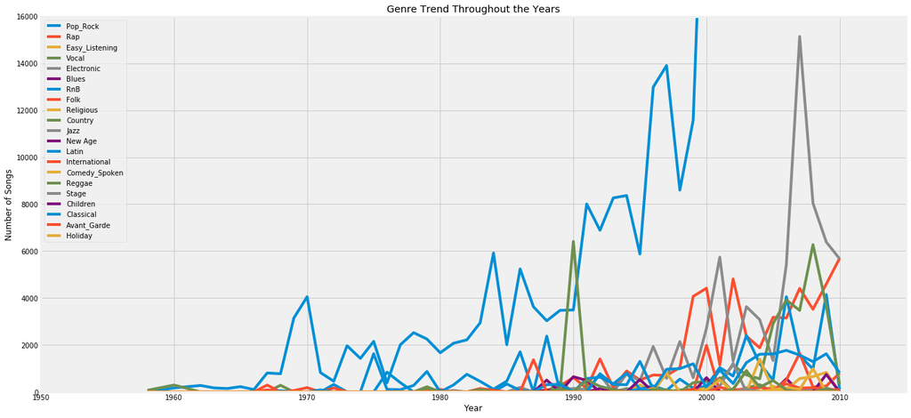

```python
# Plot each genre trend over the years
plt.figure(figsize=(20, 10))
for g in genre.genre_id.unique():
    plt.plot(year_genre['year'], year_genre[g], label=g)
    plt.xlim(1950, 2015)
    plt.ylim(0, 16000)
    plt.legend()
    plt.title('Genre Trend Throughout the Years')
    plt.xlabel('Year')
    plt.ylabel('Number of Songs')
plt.show()
```